# Multiple Imputation DOCtor (midoc)

Elinor Curnow, Jon Heron, Rosie Cornish, Kate Tilling, and James Carpenter

## About midoc

Missing data is a common issue in health and social research, often addressed by multiple imputation (MI). MI is a flexible and general approach, with a suite of software packages. However, using MI in practice can be complex. Application of MI involves multiple decisions which are rarely justified or even documented, and for which little guidance is available.

The Multiple Imputation DOCtor (`midoc`) R package is a decision-making system which incorporates expert, up-to-date guidance to help you choose the most appropriate analysis method when there are missing data. `midoc` will guide you through your analysis, examining both the hypothesised causal relationships and the observed data to advise on whether MI is needed, and if so how to perform it. `midoc` follows the framework for the treatment and reporting of missing data in observational studies (TARMOS) [1](https://doi.org/10.1016/j.jclinepi.2021.01.008). We assume you are interested in obtaining unbiased estimates of regression coefficients - note that bias is not necessarily a concern if your interest is in prediction (*i.e.* diagnostic/prognostic modelling).

Here, we will demonstrate the key features of `midoc` using a worked example.

In this example, we wish to estimate the association between maternal age at first pregnancy (our exposure) and child’s body mass index (BMI) at age 7 years (our outcome). For simplicity, we only consider one confounder of the relationship between maternal age and BMI at age 7 years, maternal education level. Note that simulated data for this study are included in the `midoc` package in the `bmi` dataset. The dataset contains 1000 observations, with realistic values for each variable, and exaggerated relationships between variables (to highlight the consequences of our choice of analysis approach).

**Note** An interactive version of this vignette: *Multiple Imputation DOCtor (midoc) Shiny version* is also available to run locally (you can run this using the `midoc` command `midocVignette()`). In the interactive version, you can apply features of `midoc` described here using your own DAG and data.

## Step 1 Specify the analysis and missingness models using a directed acyclic graph

First, we will construct a causal diagram, or directed acyclic graph (DAG) for our example, using syntax as per the [dagitty](https://doi.org/10.1093/ije/dyw341) package.

We will start by specifying the relationships between our variables, assuming there are no missing data.

We will assume maternal age (`matage`) causes BMI at age 7 years (`bmi7`), and maternal education level (`mated`) causes both maternal age and BMI at age 7 years. We can express these relationships using “dagitty” syntax, as follows:

```r
matage -> bmi7
mated -> matage
mated -> bmi7
```

Next, for each partially observed variable, we will specify the variables related to its probability of being missing (its “missingness”) by adding these relationships to our DAG. This type of DAG is often referred to as a “missingness” DAG (mDAG) [2](https://doi.org/10.1177/0962280210394469), [3](https://doi.org/10.1093/ije/dyad008).

We will first use the `midoc` function `descMissData` to identify which variables in our dataset are partially observed, specifying our outcome (`y`), covariates, *i.e.* our independent variables, (`covs`), and dataset (`data`), as follows.

```r
descMissData(y="bmi7",
             covs="matage mated",
             data=bmi)
```

```
  pattern bmi7 matage mated   n pct
1       1    1      1     1 592  59
2       2    0      1     1 408  41
```

We see that there are two missing data patterns: either all variables are observed, or BMI at age 7 years is missing and all covariates are observed. We will use indicator variable “R” to denote the missingness of BMI at age 7 years (for example, R=1 if BMI at age 7 years is observed, and 0 otherwise). In this specific example, R also indicates a complete record (R=1 if all variables are fully observed, and 0 otherwise) because all other variables are fully observed. We will suppose that R is related to maternal education level via socio-economic position (SEP), *i.e.* SEP is a cause of both maternal education level and R, but neither BMI at age 7 years itself nor maternal age are causes of R. We will further suppose that SEP is missing (unmeasured) for all individuals in our dataset; to remind us of this fact, we will name this variable `sep_unmeas`.

Our mDAG is now as follows (note that we follow the convention of using lower case names for variables in our code, so R becomes “r”, and so on):

```r
matage -> bmi7
mated -> matage
mated -> bmi7
sep_unmeas -> mated
sep_unmeas -> r
```

Note that if instead you believe maternal education is a direct cause of R, the mDAG would be as follows:

```r
matage -> bmi7
mated -> matage
mated -> bmi7
mated -> r
```

We will now draw our mDAG and visually check that the relationships are specified as we intended:

**Note** We have used additional commands to specify the layout of the mDAG shown below - although this is not necessary when using `midoc`, go to the dagitty [website](https://www.dagitty.net/) if you would like to find out more about using “dagitty” to draw mDAGs.

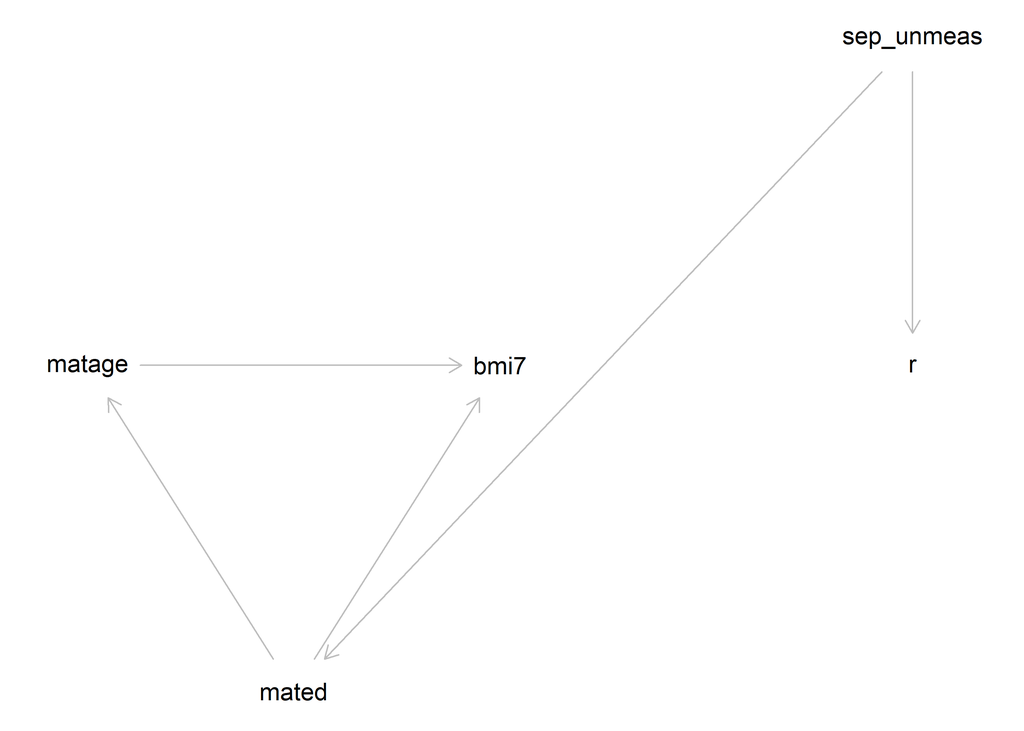

As a final check of our mDAG, we will use the `midoc` function `exploreDAG` to explore whether relationships in the dataset are consistent with the proposed mDAG, specifying both our mDAG (`mdag`) and dataset (`data`), as follows.

```r
exploreDAG(mdag="matage -> bmi7
                  mated -> matage
                  mated -> bmi7
                  sep_unmeas -> mated
                  sep_unmeas -> r",
           data=bmi)
```

```
The proposed directed acyclic graph (DAG) implies the following
conditional independencies (where, for example, 'X _||_ Y | Z' should
be read as 'X is independent of Y conditional on Z'). Note that
variable names are abbreviated:

bmi7 _||_ r | sp_n

bmi7 _||_ r | matd

bmi7 _||_ sp_n | matd

matg _||_ r | sp_n

matg _||_ r | matd

matg _||_ sp_n | matd

matd _||_ r | sp_n

These (conditional) independence statements are explored below using
the canonical correlations approach for mixed data. See
??dagitty::localTests for further details.  Results are shown for
variables that are fully observed in the specified dataset. The null
hypothesis is that the stated variables are (conditionally)
independent.

                        estimate  p.value        2.5%      97.5%

matage _||_ r | mated 0.02998323 0.343547 -0.03206946 0.09180567

Interpretation: A small p-value means the stated variables may not be
(conditionally) independent in the specified dataset: your data may not
be consistent with the proposed DAG. A large p-value means there is
little evidence of inconsistency between your data and the proposed
DAG.

Note that these results assume that relationships between variables are
linear. Consider exploring the specification of each relationship in
your model.  Also consider whether it is valid and possible to explore
relationships between partially observed variables using the observed
data, e.g. avoiding perfect prediction.
```

Based on the relationships between fully observed variables maternal age, maternal education, and missingness of BMI at age 7 years, we can see that there is little evidence of inconsistency between our dataset and proposed mDAG. In particular, our mDAG assumes that maternal age (`matage`) is unrelated to missingness of BMI at age 7 years (`r`), given maternal education (`mated`); our results suggest this is plausible. Note that we cannot use our observed data to determine whether BMI at age 7 years is unrelated to its own missingness - we would need the missing values of BMI at age 7 years in order to do this. However, if BMI at age 7 years was a cause of its own missingness, then we would expect maternal age also to be related to its missingness (via BMI at age 7 years). Since maternal age seems to be unrelated, we are reassured that BMI at age 7 years is also likely to be unrelated, given maternal education.

**Tips for specifying a “missingness” DAG**

- First specify the DAG for the analysis model, as it would be if there were no missing data. You may find this introduction to DAGs useful [4](https://doi.org/10.1038/s41390-018-0071-3).
- Next add missingness indicator(s) to your DAG. If you have multiple variables with missing data, you may want to start by including just the complete records indicator in your DAG.
- Identify variables related to missingness using:
  - Subject-matter knowledge, for example, prior research on causes of drop-out in your study and knowledge of the data collection process
  - Data exploration, for example, by performing a logistic regression of each missingness indicator on your analysis model variables - noting that you may have to exclude any variables with a large proportion of missing data to avoid perfect prediction

## Step 2 Check whether complete records analysis is likely to be a valid strategy

Our next step is to determine whether complete records analysis (CRA) is a valid strategy, using our mDAG. Remember that, in general, CRA will be valid if the analysis model outcome is unrelated to the complete records indicator, conditional on the analysis model covariates [5](https://doi.org/10.1093/ije/dyz032) (in special cases, depending on the type of analysis model and estimand of interest, this rule can be relaxed [6](https://doi.org/10.1093/aje/kwv114) - here, we will consider the general setting without making any assumptions about the fitted model).

Suppose we decide to estimate the unadjusted association between BMI at age 7 years and maternal age, without including our confounder maternal education in the model. We will use the `midoc` function `checkCRA` applied to our mDAG to check whether CRA is valid for this model, specifying our outcome (`y`), covariates, *i.e.* our independent variables, (`covs`), complete records indicator (`r_cra`), and mDAG (`mdag`), as follows:

```r
checkCRA(y="bmi7",
         covs="matage",
         r_cra="r",
         mdag="matage -> bmi7
               mated -> matage
               mated -> bmi7
               sep_unmeas -> mated
               sep_unmeas -> r")
```

```
Based on the proposed directed acyclic graph (DAG), the analysis model
outcome and complete record indicator are not independent given
analysis model covariates. Hence, in general, complete records analysis
is not valid.

In special cases, depending on the type of analysis model and estimand
of interest, complete records analysis may still be valid. See, for
example, Bartlett et al. (2015) (https://doi.org/10.1093/aje/kwv114)
for further details.

Consider using a different analysis model and/or strategy, e.g.
multiple imputation.

For example, the analysis model outcome and complete record indicator
are independent if, in addition to the specified covariates, the
following sets of variables are included as covariates in the analysis
model (note that this list is not necessarily exhaustive, particularly
if your DAG is complex):

mated

c("mated", "sep_unmeas")
```

We can see that CRA would not be valid (we can also tell this by inspecting our DAG: there is an open path from `bmi7` to `r` via `mated` and `sep_unmeas` if we only condition on `matage`). `checkCRA` suggests that CRA would be valid if we included `mated`, or `mated` and `sep_unmeas`, in the analysis model. In this particular setting, it is sensible to include `mated` in the analysis model since it is a confounder of the relationship between `matage` and `bmi7`. In other settings, we might not want to include the variables required for valid CRA in our model because they might change its interpretation - in that case, we would need to use a different analysis strategy. Note that `sep_unmeas` is not related to `bmi7` once we condition on `mated` (though it is still related to missingness of `bmi7`), so does not need to be included in our analysis model.

If we add `mated` to the model and re-run `checkCRA`, as below, we see that CRA is now valid.

```r
checkCRA(y="bmi7",
         covs="matage mated",
         r_cra="r",
         mdag="matage -> bmi7
               mated -> matage
               mated -> bmi7
               sep_unmeas -> mated
               sep_unmeas -> r")
```

```
Based on the proposed directed acyclic graph (DAG), the analysis model
outcome and complete record indicator are independent given analysis
model covariates. Hence, complete records analysis is valid.
```

**Note** If our outcome, BMI at age 7 years, was itself a cause of missingness, CRA would always be invalid, *i.e.* there would be no other variables we could add to the analysis model to make CRA valid. See below to see the results of `checkCRA` in this case (note, in the code, we have added a path from `bmi7` to `r` to the specified mDAG).

```r
checkCRA(y="bmi7",
         covs="matage mated",
         r_cra="r",
         mdag="matage -> bmi7
               mated -> matage
               mated -> bmi7
               sep_unmeas -> mated
               sep_unmeas -> r
               bmi7 -> r")
```

```
Based on the proposed directed acyclic graph (DAG), the analysis model
outcome and complete record indicator are not independent given
analysis model covariates. Hence, in general, complete records analysis
is not valid.

In special cases, depending on the type of analysis model and estimand
of interest, complete records analysis may still be valid. See, for
example, Bartlett et al. (2015) (https://doi.org/10.1093/aje/kwv114)
for further details.

There are no other variables which could be added to the model to make
the analysis model outcome and complete record indicator conditionally
independent. Consider using a different strategy e.g. multiple
imputation.
```

## Step 3 Check whether multiple imputation is likely to be a valid strategy

Although CRA is valid for our example, we may also wish to perform MI. Remember that MI is valid in principle if each partially observed variable is unrelated to its missingness, given its imputation model predictors. Furthermore, we should include all other analysis model variables in the imputation model for each partially observed variable, in the form implied by the analysis model, so that the analysis and imputation models are “compatible”. In theory, given multiple partially observed variables, validity of MI may imply different causes of missingness for each missing data pattern. For example, if both BMI at age 7 years and maternal education were partially observed, MI would only be valid if missingness of BMI at age 7 years was unrelated to maternal education among individuals missing both BMI at age 7 years and maternal education (given the other observed data). Missingness of BMI at age 7 years could be related to maternal education among individuals with observed maternal education. In practice, we recommend focusing on the most common missing data patterns and/or variables with the most missing data. Less common missing data patterns can often be assumed to be missing completely at random - it is unlikely to change your final conclusions if this assumption is incorrect.

In our example, we only have a single partially observed variable (BMI at age 7 years), so it is relatively simple to check the validity of MI based on our mDAG. We have already verified (using `checkCRA`) that BMI at age 7 years is unrelated to its missingness, given maternal age and maternal education. Therefore, we know that MI will be valid if we use only these variables in the imputation model for BMI at age 7 years (because the analysis model and the imputation model are exactly the same in this case). However, MI using just maternal age and maternal education in the imputation model for BMI at age 7 years will recover no additional information compared to CRA. Therefore, we may wish to include “auxiliary variables” in our imputation model for BMI at age 7 years. These are additional variables that are included as predictors in the imputation model but that are not required for the analysis model. If we choose auxiliary variables that are predictive of BMI at age 7 years, we can improve the precision of our MI estimate - reduce its standard error - compared to the CRA estimate.

In our example, we have two variables that could be used as auxiliary variables: pregnancy size - singleton or multiple birth - (`pregsize`) and birth weight (`bwt`). We will inspect the missing data patterns in our dataset once again using `descMissData`, including our auxiliary variables.

```r
descMissData(y="bmi7",
             covs="matage mated pregsize bwt",
             data=bmi)
```

```
  pattern bmi7 matage mated pregsize bwt   n pct
1       1    1      1     1        1   1 592  59
2       2    0      1     1        1   1 408  41
```

We can see that our auxiliary variables are fully observed.

We assume that pregnancy size is a cause of BMI at age 7 years, but not its missingness. We assume birth weight is related to both BMI at 7 years (via pregnancy size) and its missingness (via SEP). We will now add these variables to our mDAG. Below, we have shown our updated mDAG.

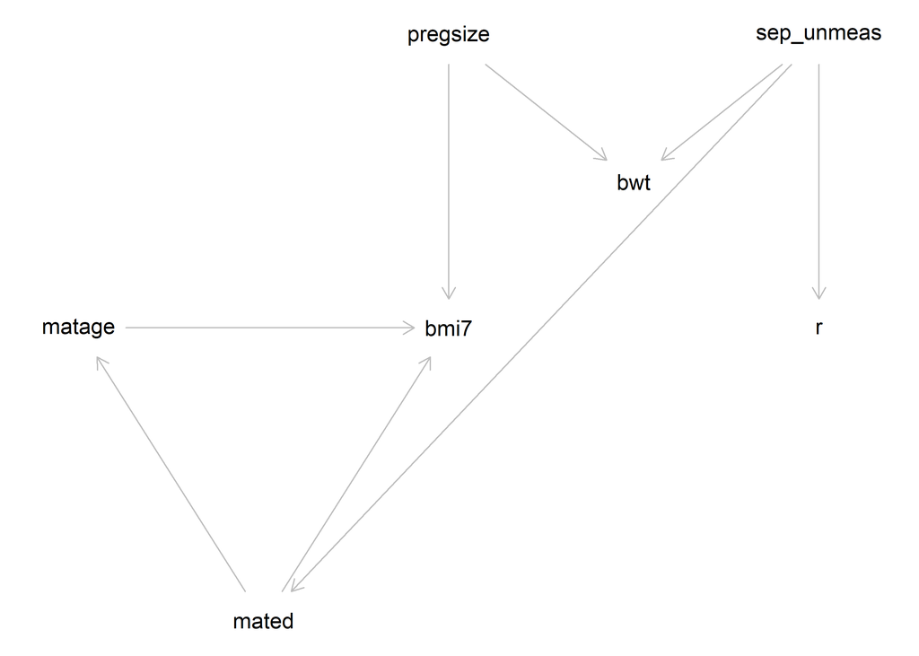

We will also once again explore whether relationships in the dataset are consistent with the updated mDAG using `exploreDAG`, as follows.

```r
exploreDAG(mdag="matage -> bmi7
                  mated -> matage
                  mated -> bmi7
                  sep_unmeas -> mated
                  sep_unmeas -> r
                  pregsize -> bmi7
                  pregsize -> bwt
                  sep_unmeas -> bwt",
           data=bmi)
```

```
The proposed directed acyclic graph (DAG) implies the following
conditional independencies (where, for example, 'X _||_ Y | Z' should
be read as 'X is independent of Y conditional on Z'). Note that
variable names are abbreviated:

bmi7 _||_ bwt | prgs, sp_n

bmi7 _||_ bwt | matd, prgs

bmi7 _||_ r | sp_n

bmi7 _||_ r | matd

bmi7 _||_ sp_n | matd

bwt _||_ matg | matd

bwt _||_ matg | sp_n

bwt _||_ matd | sp_n

bwt _||_ r | sp_n

matg _||_ prgs

matg _||_ r | sp_n

matg _||_ r | matd

matg _||_ sp_n | matd

matd _||_ prgs

matd _||_ r | sp_n

prgs _||_ r

prgs _||_ sp_n

These (conditional) independence statements are explored below using
```

[output cut: 14 more lines]

```
mated _||_ pregsize     0.01594976 0.6144181 -0.04608889 0.07786585

pregsize _||_ r         0.01482015 0.6397174 -0.04721631 0.07674273

Interpretation: A small p-value means the stated variables may not be
(conditionally) independent in the specified dataset: your data may not
be consistent with the proposed DAG. A large p-value means there is
little evidence of inconsistency between your data and the proposed
DAG.

Note that these results assume that relationships between variables are
linear. Consider exploring the specification of each relationship in
your model.  Also consider whether it is valid and possible to explore
relationships between partially observed variables using the observed
data, e.g. avoiding perfect prediction.
```

Our results suggest that our updated mDAG is plausible.

Note that CRA is still valid for our updated mDAG. We can check this using `checkCRA` once more:

```r
checkCRA(y="bmi7",
         covs="matage mated",
         r_cra="r",
         mdag="matage -> bmi7
               mated -> matage
               mated -> bmi7
               sep_unmeas -> mated
               sep_unmeas -> r
               pregsize -> bmi7
               pregsize -> bwt
               sep_unmeas -> bwt")
```

```
Based on the proposed directed acyclic graph (DAG), the analysis model
outcome and complete record indicator are independent given analysis
model covariates. Hence, complete records analysis is valid.
```

We will now use the `midoc` function `checkMI` applied to our DAG to check whether MI is valid when the imputation model predictors for BMI at age 7 years include pregnancy size or birth weight, as well as maternal age and maternal education. We will specify the partially observed variable (`dep`), predictors (`preds`), missingness indicator for the partially observed variable (`r_dep`), and mDAG (`mdag`).

We will first consider the imputation model including pregnancy size. The results are shown below. These suggest that MI would be valid in principle if we included pregnancy size as well as the other analysis model variables in the imputation model for BMI at age 7 years.

```r
checkMI(dep="bmi7",
        preds="matage mated pregsize",
        r_dep="r",
        mdag="matage -> bmi7
              mated -> matage
              mated -> bmi7
              sep_unmeas -> mated
              sep_unmeas -> r
              pregsize -> bmi7
              pregsize -> bwt
              sep_unmeas -> bwt")
```

```
Based on the proposed directed acyclic graph (DAG), the incomplete
variable and its missingness indicator are independent given imputation
model predictors. Hence, multiple imputation methods which assume data
are missing at random are valid in principle.
```

We will next consider the imputation model including birth weight. The results are shown below. These suggest that MI would not be valid if we included birth weight as well as the other analysis model variables in the imputation model for BMI at age 7 years. We can also tell this by inspecting our mDAG: since `bwt` shares a common cause with both `bmi7` and `r`, it is a “collider”, and hence conditioning on `bwt` opens a path from `bmi7` to `r` via `bwt`.

```r
checkMI(dep="bmi7",
        preds="matage mated bwt",
        r_dep="r",
        mdag="matage -> bmi7
              mated -> matage
              mated -> bmi7
              sep_unmeas -> mated
              sep_unmeas -> r
              pregsize -> bmi7
              pregsize -> bwt
              sep_unmeas -> bwt")
```

```
Based on the proposed directed acyclic graph (DAG), the incomplete
variable and its missingness indicator are not independent given
imputation model predictors. Hence, multiple imputation methods which
assume data are missing at random are not valid.

Consider using a different imputation model and/or strategy (e.g.
not-at-random fully conditional specification).  For example, the
incomplete variable and its missingness indicator are independent if,
in addition to the specified predictors, the following sets of
variables are included as predictors in the imputation model (note that
this list is not necessarily exhaustive, particularly if your DAG is
complex):

pregsize

c("pregsize", "sep_unmeas")
```

**Note** In theory, and as suggested by the `checkMI` results shown above, MI would be valid if we added both birth weight and pregnancy size as auxiliary variables in our imputation model (note that SEP is not needed, conditional on the other imputation model predictors). However, in practice, this strategy may still result in biased estimates, due to unmeasured confounding of the relationship between BMI at age 7 years and birth weight. We recommend not including colliders of the partially observed variable and its missingness as auxiliary variables 7.

## Step 4 Check that all relationships are correctly specified

So far, we have explored whether CRA and MI are valid *in principle* using our mDAG, without making any assumptions about the form of our variables, or their relationships with each other.

However, for MI to give unbiased estimates, imputation models must be both compatible with the analysis model and correctly specified: they must contain all the variables required for the analysis model, they must include all relationships implied by the analysis model e.g. interactions, and they must specify the form of all relationships correctly [8](https://doi.org/10.1016/j.jclinepi.2023.06.011).

Since CRA and MI are valid in principle for our worked example, we will use the complete records in the `bmi` dataset to explore the specification of relationships between BMI at age 7 years and its predictors (the analysis model variables, maternal age and maternal education, plus auxiliary variable, pregnancy size) in its imputation model.

We will use the `midoc` function `checkModSpec` applied to the `bmi` dataset to check whether our imputation model is correctly specified. We will specify the formula for the imputation model using standard R syntax (`formula`), the type of imputation model (`family`) (note that `midoc` currently supports either linear or logistic regression models), and the name of the dataset (`data`).

Since maternal education and pregnancy size are binary variables, we only need to explore the form of the relationship between BMI at age 7 years and our continuous exposure, maternal age. We will first assume there is a linear relationship between BMI at age 7 years and maternal age (note, this is the default in most software implementations of MI). We will assume there are no interactions.

The results are shown below. These suggest that our imputation model is mis-specified. A plot of the residuals versus the fitted values from our model (which is automatically displayed if there is evidence of model mis-specification), suggests there may be a quadratic relationship between BMI at age 7 years and maternal age.

```r
checkModSpec(formula="bmi7~matage+mated+pregsize",
             family="gaussian(identity)",
             data=bmi)
```

```
Model mis-specification method: regression of model residuals on a
fractional polynomial of the fitted values

P-value: 0

A small p-value means the model may be mis-specified. Check the
specification of each relationship in your model.
```

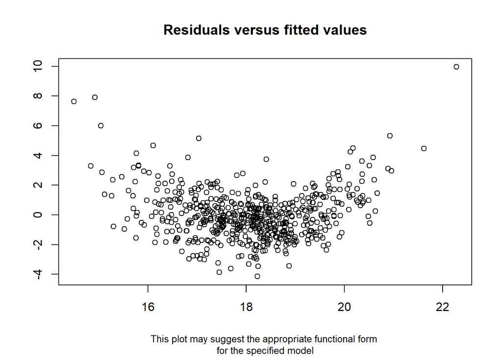

We will use the `midoc` function `checkModSpec` again, this time specifying a quadratic relationship between BMI at age 7 years and maternal age.

The results below suggest there is no longer evidence of model mis-specification.

```r
checkModSpec(formula="bmi7~matage+I(matage^2)+mated+pregsize",
             family="gaussian(identity)",
             data=bmi)
```

```
Model mis-specification method: regression of model residuals on a
fractional polynomial of the fitted values

P-value: 1

A large p-value means there is little evidence of model
mis-specification.
```

**Note** We must make sure we account for the non-linear relationship between BMI at age 7 years and maternal age in all other imputation models. For example, the imputation model for pregnancy size would need to include BMI at age 7 years, maternal education, and a quadratic form of maternal age (induced by conditioning on BMI at age 7 years). Although there are no missing values for pregnancy size in our dataset, we can still explore the specification that we would need using `checkModSpec` as follows (note that we have suppressed the plot in this case using the `plot = FALSE` option):

```r
checkModSpec(formula="pregsize~matage+bmi7+mated",
             family="binomial(logit)",
             data=bmi,
             plot=FALSE)
```

```
Model mis-specification method: Pregibon's link test

P-value: 0.038313

A small p-value means the model may be mis-specified. Check the
specification of each relationship in your model.
```

There is some evidence of model mis-specification.

Once we include a quadratic form of maternal age in our model for pregnancy size, there is little evidence of model mis-specification:

```r
checkModSpec(formula="pregsize~matage+I(matage^2)+bmi7+mated",
             family="binomial(logit)",
             data=bmi)
```

```
Model mis-specification method: Pregibon's link test

P-value: 0.555356

A large p-value means there is little evidence of model
mis-specification.
```

**Tips for imputation model variable selection**

- The imputation model for each partially observed variable should include:
  1. All analysis model variables - check that all relationships between the partially observed variable and its predictors are correctly specified in the imputation model *e.g.* using fractional polynomial selection
  2. All auxiliary variables that are related to both missingness of the partially observed variable and the missing data itself, conditional on the analysis model variables
  3. Auxiliary variables that are related to the missing data but not missingness of the partially observed variable, conditional on the variables selected in Steps 1 and 2 above - if there are a large number of such variables, only include the most predictive in the imputation model (using a suitable variable selection method to identify these)
- The imputation model for each partially observed variable should exclude:
  - All auxiliary variables that are related to missingness of the partially observed variable but not the missing data, conditional on the variables selected in Steps 1, 2, and 3 above
  - All auxiliary variables that are colliders of the partially observed variable and its missingness

## Step 5 Perform MI using the proposed imputation model

We have explored both the validity of MI in principle, using our mDAG, and the specification of our imputation model, based on our observed data. We will now use the `midoc` function `proposeMI` to choose the best options when performing MI using the [mice](https://doi.org/10.18637/jss.v045.i03) package. We will first save our chosen imputation model (*i.e.* specifying a quadratic relationship between BMI at age 7 years and maternal age) as a `mimod` object. Note we have suppressed the `checkModSpec` message in this case using the `message = FALSE` option. We will then use this, along with our dataset, to construct our call of the “mice” function. Note we will also save our proposed “mice” call as a `miprop` object, to be used later.

The results are shown below. In particular, note that in the proposed “mice” call, the default values for the number of imputations, method, formulas, and number of iterations have been changed. Plots of the distributions of imputed and observed data, based on a sample of five imputed datasets, suggest that extreme values are handled appropriately using the proposed imputation method. Trace plots, showing the mean and standard deviation of the imputed values across iterations, are also displayed. Note that both plots are shown without prompting (`plotprompt = FALSE`). There is no need to adjust the number of iterations when, as in our dataset, only one variable is partially observed.

[output not shown]

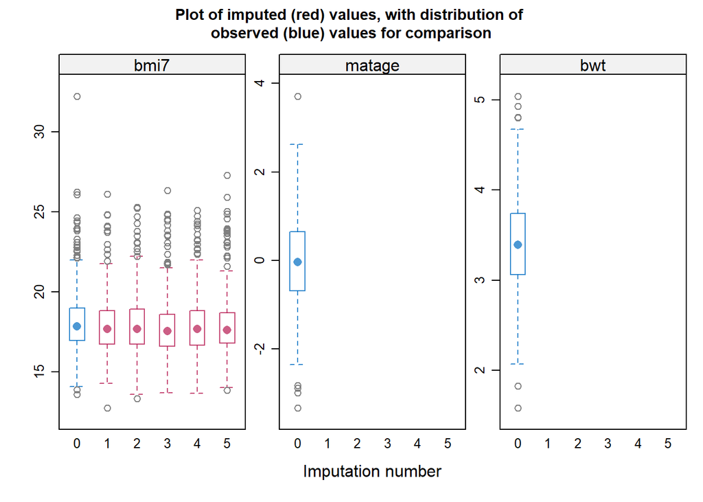

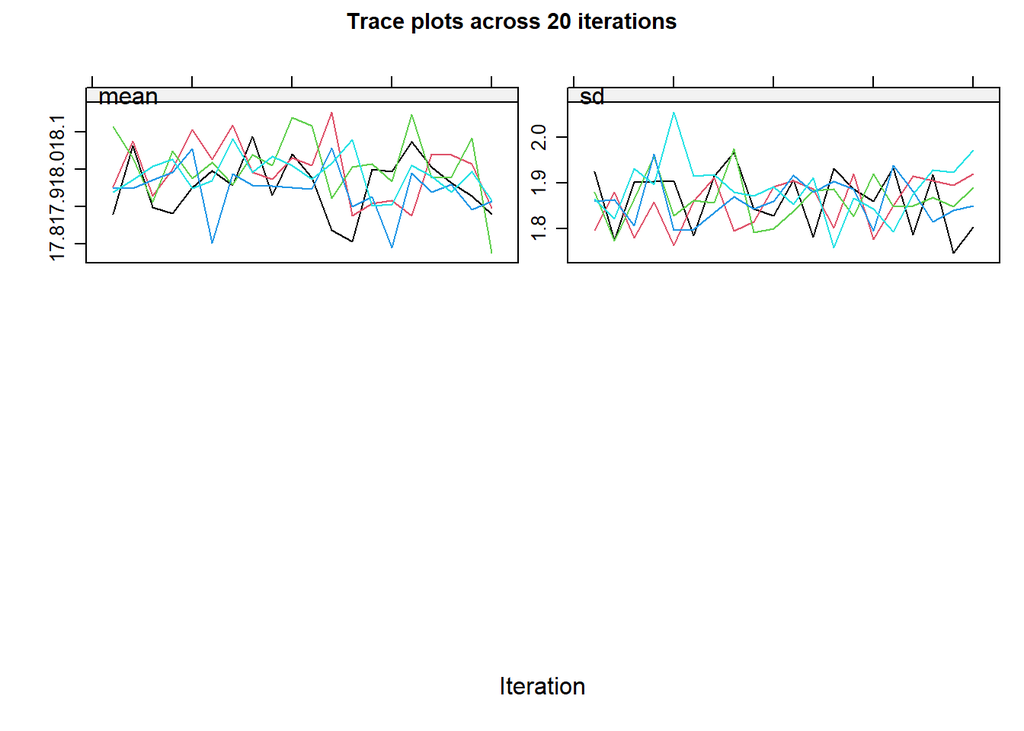

```r
mimod_bmi7 <- checkModSpec(formula="bmi7~matage+I(matage^2)+mated+pregsize",
                           family="gaussian(identity)",
                           data=bmi,
                           message=FALSE)
miprop <- proposeMI(mimodobj=mimod_bmi7,
                    data=bmi,
                    plotprompt=FALSE)
```

**Note** Given multiple partially observed variables, we can specify a list of imputation models - one for each partially observed variable - in `proposeMI`. For example, suppose pregnancy size was also partially observed. We will assume, for simplicity, that pregnancy size was missing completely at random. Then we could construct our proposed “mice” call using `proposeMI`, as follows. Here, we again suppress the model checking messages.

```r
mimod_bmi7 <- checkModSpec(formula="bmi7~matage+I(matage^2)+mated+pregsize",
                           family="gaussian(identity)",
                           data=bmi,
                           message=FALSE)
mimod_pregsize <- checkModSpec(formula="pregsize~bmi7+matage+I(matage^2)+mated",
                               family="binomial(logit)",
                               data=bmi,
                               message=FALSE)
proposeMI(mimodobj=list(mimod_bmi7, mimod_pregsize),
          data=bmi)
```

Returning to our example, we will assume no further adjustment is required to the proposed “mice” call. We will use the `midoc` function `doMImice` to perform MI, specifying our proposed “mice” call (`miprop`) and the seed for our “mice” call (`seed`) (so that our results are reproducible). We will also specify our substantive model of interest (`substmod`): a regression of BMI at 7 years on maternal age (fitting a quadratic relationship) and maternal education. This is an optional step: if we specify the substantive model, it will be fitted automatically to each imputed dataset and the pooled results will be displayed (equivalent to using the “mice” functions `with` and `pool`). If the substantive model is not specified, only the imputation step will be performed.

```r
doMImice(miprop, seed=123, substmod="lm(bmi7 ~ matage + I(matage^2) + mated)")
```

```
Given the substantive model: lm(bmi7 ~ matage + I(matage^2) + mated) ,
multiple imputation estimates are as follows:

         term   estimate  std.error  statistic       df       p.value

1 (Intercept) 17.6607324 0.07126548 247.816079 233.1668 2.116834e-284

2      matage  1.1504545 0.05230345  21.995769 184.5081  1.863532e-53

3 I(matage^2)  0.8414975 0.03231752  26.038433 257.1270  4.754845e-74

4      mated1 -1.0026194 0.10787751  -9.294054 159.1101  1.094881e-16

       2.5 %     97.5 %

1 17.5203258 17.8011389

2  1.0472648  1.2536442

3  0.7778567  0.9051382

4 -1.2156760 -0.7895629
```

## Illustration using our worked example

Finally, we illustrate how our choice of analysis approach affects the estimated association between maternal age and BMI at age 7 years, adjusted for maternal education level. We compare CRA and MI estimates. When performing MI, we used either pregnancy size or birth weight as an auxiliary variable and fitted either a linear or quadratic relationship between BMI at age 7 years and maternal age in the imputation model. For each analysis approach, we fitted the same substantive analysis model that we used above.

The parameter estimates for the linear and quadratic terms of maternal age, and their 95% confidence intervals, are shown in the table below. Note that, because we have simulated the data and its missingness, we know the “true” association *i.e.* the association if there were no missing data - this is shown in the “Full data” row of the table. Further note that the results displayed in the third row (“MI fitting quadratic relationship, using pregnancy size”) are exactly those generated above. To avoid repetition, we have not shown the code for fitting the other models.

From the table, we can see that both CRA and MI (fitting a quadratic relationship between BMI at age 7 years and maternal age in the imputation model) estimates are unbiased for both the linear and quadratic terms of maternal age. MI estimates are biased when fitting a linear relationship in the imputation model, particularly for the quadratic term of maternal age. MI estimates using the collider, birth weight, as an auxiliary variable are slightly more biased and slightly less precise than the estimates using pregnancy size as an auxiliary variable. The collider bias is relatively small because the association between BMI at age 7 years and maternal age is strong in this setting. Note that the collider bias could be relatively larger if the association was weak [9](https://doi.org/10.3389/fepid.2023.1237447).

Parameter estimates for maternal age

| Approach | Linear term | Quadratic term |
| --- | --- | --- |
| Full data | 1.17 (1.09-1.26) | 0.86 (0.80-0.91) |
| CRA | 1.16 (1.05-1.26) | 0.84 (0.77-0.90) |
| MI fitting quadratic relationship, using pregnancy size | 1.15 (1.05-1.25) | 0.84 (0.78-0.91) |
| MI fitting quadratic relationship, using birth weight | 1.16 (1.05-1.27) | 0.83 (0.77-0.90) |
| MI fitting linear relationship, using pregnancy size | 1.21 (1.07-1.34) | 0.54 (0.46-0.62) |
| MI fitting linear relationship, using birth weight | 1.20 (1.07-1.34) | 0.53 (0.45-0.61) |